# Practical 6 Supervised learning: Classification 2

Supervised Learning & Visualization

Ernst Paul Swens

November, 2022

# Q1

**Create a logistic regression model lr_mod for this data using the formula response ~ . and create a confusion matrix based on a .5 cutoff probability.**

```r
cvd <- read.csv("Data/cardiovascular_treatment.csv")

lr_mod <- glm(response ~ ., data = cvd, family = binomial())

pred <- predict(lr_mod, type = "response") > 0.5
true <- cvd$response == 1

table(true = true, pred = pred)
```

```
##        pred
## true    FALSE TRUE
##   FALSE    78   49
##   TRUE     35   91
```

# Q2

**Calculate the accuracy, true positive rate (sensitivity), the true negative rate (specificity), the false positive rate, the positive predictive value, and the negative predictive value. You can use the confusion matrix table on wikipedia. What can you say about the model performance? Which metrics are most relevant if this model were to be used in the real world?**

```r
TN <- 78
FN <- 35
FP <- 49
TP <- 91

(TP + TN) / (TN + FN + FP + TP) # accuracy
```

```
## [1] 0.6679842
```

```r
TP / (TP + FN) # tpr
```

```
## [1] 0.7222222
```

```r
TN / (TN + FP) # tnr
```

```
## [1] 0.6141732
```

```r
FP / (TN + FP) # fpr
```

```
## [1] 0.3858268
```

```r
TP / (TP + FP) # ppv
```

```
## [1] 0.65
```

```r
TN / (TN + FN) # npv
```

```
## [1] 0.6902655
```

# Q3

**Create an LDA model `lda_mod` for the same prediction problem. Compare its performance to the LR model.**

```r
lda_mod <- lda(response ~ ., data = cvd)

pred <- predict(lda_mod, type = "response")$class == "1"

table(true = true, pred = pred)
```

```
##        pred
## true    FALSE TRUE
##   FALSE    78   49
##   TRUE     35   91
```

```r
# lda confusion matrix is identical
```

# Q4

**Compare the classification performance of `lr_mod` and `lda_mod` for the new patients in the `data/new_patients.csv`.**

```r
cvd_new <- read.csv("Data/new_patients.csv")

true <- cvd_new$response == 1

lr_pred <- predict(lr_mod, newdata = cvd_new, type = "response") > .5

lda_pred <- predict(lda_mod, newdata = cvd_new)$class == 1

table(true = true, pred = lr_pred)
```

```
##        pred
## true    FALSE TRUE
##   FALSE    16   11
##   TRUE      8   15
```

```r
table(true = true, pred = lda_pred)
```

```
##        pred
## true    FALSE TRUE
##   FALSE    17   10
##   TRUE      8   15
```

# Q5

**Create two LR models: `lr1_mod` with `severity`, `age`, and `bb_score` as predictors, and `lr2_mod` with the formula `response ~ age + I(age^2) + gender + bb_score * prior_cvd * dose`. Save the predicted probabilities on the training data.**

```r
lr1_mod <- glm(
   response ~ severity + age + bb_score,
   data = cvd,
   family = binomial()
)

lr2_mod <- glm(
   response ~ age + I(age^2) + gender + bb_score * prior_cvd * dose,
   data = cvd,
   family = binomial()
)

pred_lr1_mod <- predict(lr1_mod, type = "response")
pred_lr2_mod <- predict(lr2_mod, type = "response")
```

# Q6

**Use the function `roc()` from the `pROC` package to create two ROC objects with the predicted probabilities: `roc_lr1` and `roc_lr2`. Use the `ggroc()` method on these objects to create an ROC curve plot for each. Which model performs better? Why?**

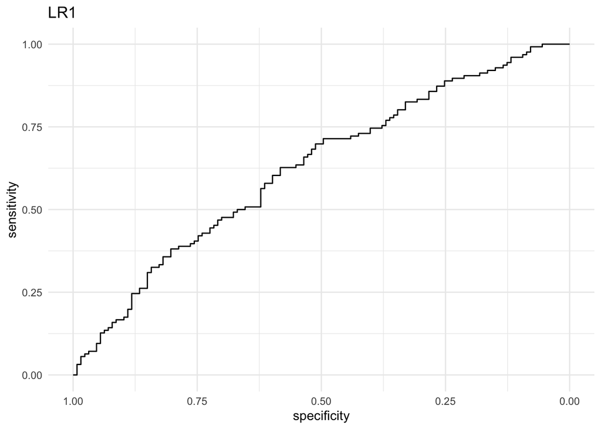

```r
roc_lr1 <- roc(cvd$response, pred_lr1_mod)
roc_lr2 <- roc(cvd$response, pred_lr2_mod)
ggroc(roc_lr1) + theme_minimal() + labs(title = "LR1")
```

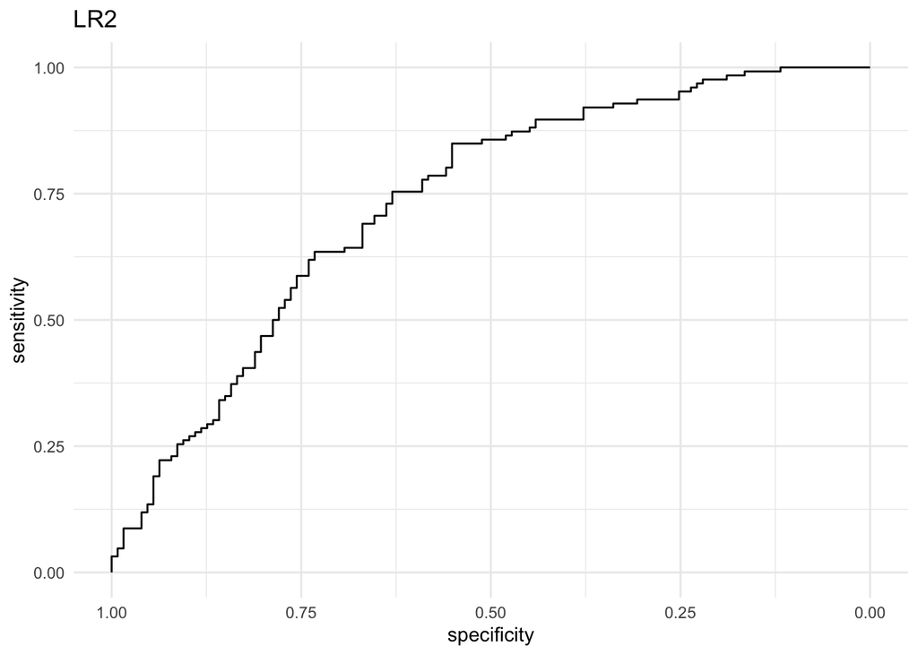

```r
ggroc(roc_lr2) + theme_minimal() + labs(title = "LR2")
```

# Q7

**Print the `roc_lr1` and `roc_lr2` objects. Which AUC value is higher? How does this relate to the plots you made before? What is the minimum AUC value and what would a “perfect” AUC value be and how would it look in a plot?**

```r
print(roc_lr1)
```

```
##
## Call:
## roc.default(response = cvd$response, predictor = pred_lr1_mod)
##
## Data: pred_lr1_mod in 127 controls (cvd$response 0) < 126 cases (cvd$response 1).
## Area under the curve: 0.6253
```

```r
print(roc_lr2)
```

```
##
## Call:
## roc.default(response = cvd$response, predictor = pred_lr2_mod)
##
## Data: pred_lr2_mod in 127 controls (cvd$response 0) < 126 cases (cvd$response 1).
## Area under the curve: 0.7325
```

```r
# second model has a higher area under the curve
# maximum value would be approaching 1
# minimum value would be 0.5
```

# Q8

**Explore the iris dataset using summaries and plots.**

```r
summary(iris)
```

```
##   Sepal.Length    Sepal.Width     Petal.Length    Petal.Width
##  Min.   :4.300   Min.   :2.000   Min.   :1.000   Min.   :0.100
##  1st Qu.:5.100   1st Qu.:2.800   1st Qu.:1.600   1st Qu.:0.300
##  Median :5.800   Median :3.000   Median :4.350   Median :1.300
##  Mean   :5.843   Mean   :3.057   Mean   :3.758   Mean   :1.199
##  3rd Qu.:6.400   3rd Qu.:3.300   3rd Qu.:5.100   3rd Qu.:1.800
##  Max.   :7.900   Max.   :4.400   Max.   :6.900   Max.   :2.500
##        Species
##  setosa    :50
##  versicolor:50
##  virginica :50
##
##
##
```

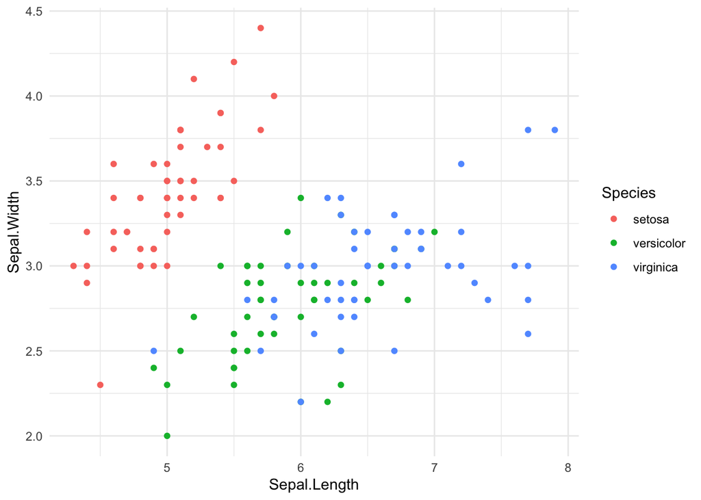

```r
iris %>%
   ggplot(aes(x = Sepal.Length, y = Sepal.Width, color = Species)) +
   geom_point() +
   theme_minimal()
```

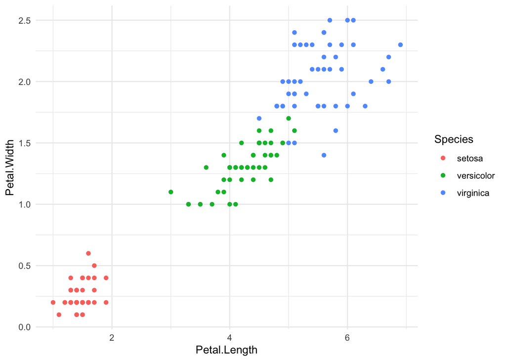

```r
iris %>%
   ggplot(aes(x = Petal.Length, y = Petal.Width, color = Species)) +
   geom_point() +
   theme_minimal()
```

# Q9

**Fit an additional LDA model, but this time with only `Sepal.Length` and `Sepal.Width` as predictors. Call this model `lda_iris_sepal`**

```r
# full model
lda_iris <- lda(Species ~ ., data = iris)

# speal model
lda_iris_sepal <- lda(Species ~ Sepal.Length + Sepal.Width, data = iris)
```